# SPOOKY Data Analysis and Inference

Kenny Warner krw2133

February 5, 2018

# Introduction

This files contains text mining analysis of the SPOOKY data. It begins with basic analysis and works to explain further techniques and more advanced analysis that can help identify text by certain authors. You should be able to put this file in the `doc` folder of your `Project 1` repository and it should just run (provided you have `multiplot.R` in the `libs` folder and `spooky.csv` in the `data` folder).

## Setup the libraries

First we want to install and load libraries we need along the way. Note that the following code is completely reproducible – you don’t need to add any code on your own to make it run.

```r
packages.used <- c("ggplot2", "dplyr", "tibble", "tidyr",  "stringr", "tidytext", "topicmodels", "wordcloud", "ggridges")

# check packages that need to be installed.
packages.needed <- setdiff(packages.used, intersect(installed.packages()[,1], packages.used))

# install additional packages
if(length(packages.needed) > 0) {
  install.packages(packages.needed, dependencies = TRUE, repos = 'http://cran.us.r-project.org')
}

library(ggplot2)
library(dplyr)
library(tibble)
library(tidyr)
library(stringr)
library(tidytext)
library(topicmodels)
library(wordcloud)
library(ggridges)

source("../libs/multiplot.R")
```

## Read in the data

The following code assumes that the dataset `spooky.csv` lives in a `data` folder (and that we are inside a `docs` folder).

```r
spooky <- read.csv('../data/spooky.csv', as.is = TRUE)
```

## An overview of the data structure and content

Let’s first remind ourselves of the structure of the data.

```r
head(spooky)
```

```
##        id
## 1 id26305
## 2 id17569
## 3 id11008
## 4 id27763
## 5 id12958
## 6 id22965
##                                                                                                                                                                                                                                                                                                          …
## 1                                                                                                                                                                                                                                              This process, however, afforded me no means of ascertainin…
## 2                                                                                                                                                                                                                                                                                                        …
## 3                                                                                                                                                                                                                                                                             In his left hand was a gold…
## 4                                                                                                                                                                                                                                                                       How lovely is spring As we looked…
## 5                                                                                                                                                                                                                                                                                                       F…
## 6 A youth passed in solitude, my best years spent under your gentle and feminine fosterage, has so refined the groundwork of my character that I cannot overcome an intense distaste to the usual brutality exercised on board ship: I have never believed it to be necessary, and when I heard of a mari…
##   author
## 1    EAP
## 2    HPL
## 3    EAP
## 4    MWS
## 5    HPL
## 6    MWS
```

```r
summary(spooky)
```

```
##       id                text              author
##  Length:19579       Length:19579       Length:19579
##  Class :character   Class :character   Class :character
##  Mode  :character   Mode  :character   Mode  :character
```

We see from the above that each row of our data contains a unique ID, a single sentence text excerpt, and an abbreviated author name. `HPL` is Lovecraft, `MWS` is Shelly, and `EAP` is Poe. We finally note that there are no missing values, and we change author name to be a factor variable, which will help us later on.

```r
sum(is.na(spooky))
```

```
## [1] 0
```

```r
spooky$author <- as.factor(spooky$author)
```

## Data Cleaning

We first use the `unnest_tokens()` function to drop all punctuation and transform all words into lower case. At least for now, the punctuation isn’t really important to our analysis – we want to study the words. In addition, `tidytext` contains a dictionary of stop words, like “and” or “next”, that we will get rid of for our analysis, the idea being that the non-common words (…maybe the SPOOKY words) that the authors use will be more interesting. If this is new to you, here’s a textbook that can help: *[Text Mining with R; A Tidy Approach](https://www.tidytextmining.com)*. It teaches the basic handling of natural language data in `R` using tools from the “tidyverse”. The tidy text format is a table with one token per row, where a token is a word.

```r
# Make a table with one word per row including common words
spooky_wrd <- unnest_tokens(spooky, word, text)
write.csv(spooky_wrd, "spooky_wrd.csv")


# Make a table with one word per row and remove `stop words` (i.e. the common words).
spooky_wrd_stop <- unnest_tokens(spooky, word, text)

spooky_wrd_stop <- anti_join(spooky_wrd, stop_words, by = "word")
```

## Word Frequency

Now we study some of the most common words in the entire data set. With the below code we plot the fifty most common words in the entire datset. We see that “time”, “life”, and “night” all appear frequently.

```r
# Words is a list of words, and freqs their frequencies
words <- count(group_by(spooky_wrd, word))$word
freqs <- count(group_by(spooky_wrd, word))$n

head(sort(freqs, decreasing = TRUE))
```

```
## [1] 35585 20955 17956 12842 10749 10736
```

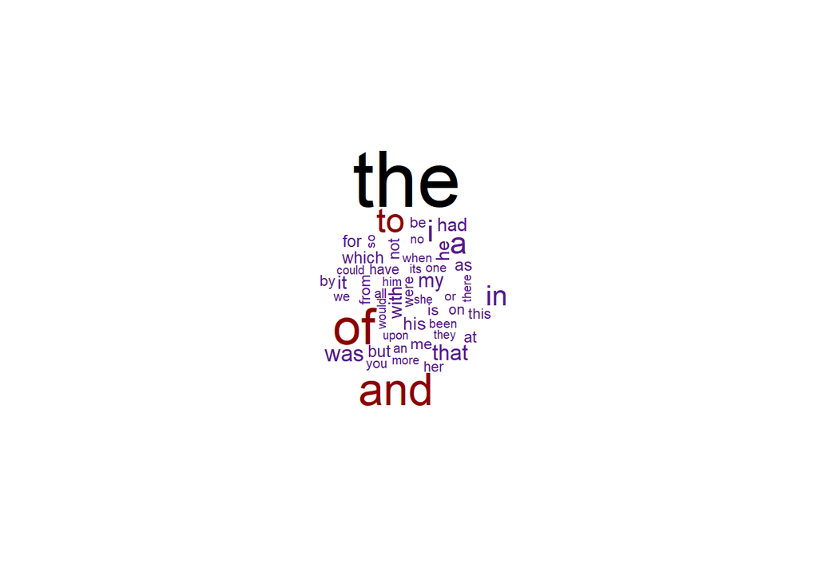

```r
wordcloud(words, freqs, max.words = 50, color = c("purple4", "red4", "black"))
```

```r
# Words_stop is a list of words, and freqs their frequencies from the list of commmon words
words_stop <- count(group_by(spooky_wrd_stop, word))$word
freqs_stop <- count(group_by(spooky_wrd_stop, word))$n

head(sort(freqs, decreasing = TRUE))
```

```
## [1] 35585 20955 17956 12842 10749 10736
```

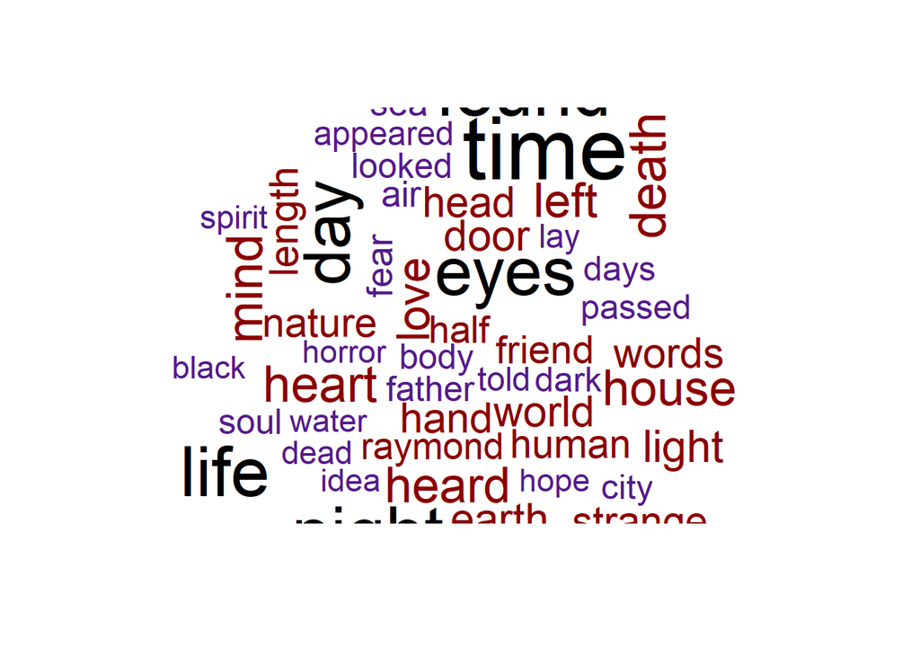

```r
wordcloud(words_stop, freqs_stop, max.words = 50, color = c("purple4", "red4", "black"))
```

We can compare the way the authors use the most frequent words too.

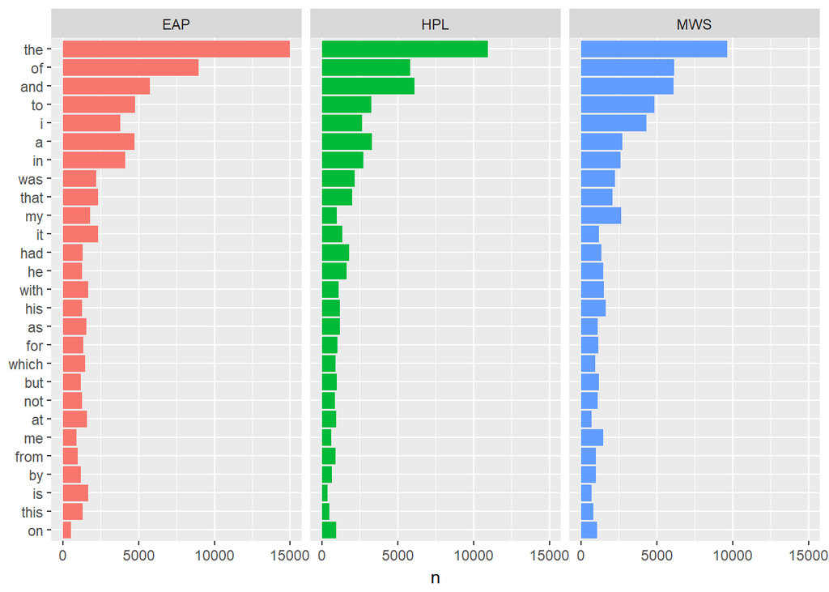

```r
# Counts number of times each author used each wor with stop words
author_words <- count(group_by(spooky_wrd, word, author))

# Counts number of times each word was use with stop words
all_words    <- rename(count(group_by(spooky_wrd, word)), all = n)

author_words <- left_join(author_words, all_words, by = "word")
author_words <- arrange(author_words, desc(all))
author_words <- ungroup(head(author_words, 81))

ggplot(author_words) +
  geom_col(aes(reorder(word, all, FUN = min), n, fill = author)) +
  xlab(NULL) +
  coord_flip() +
  facet_wrap(~ author) +
  theme(legend.position = "none")
```

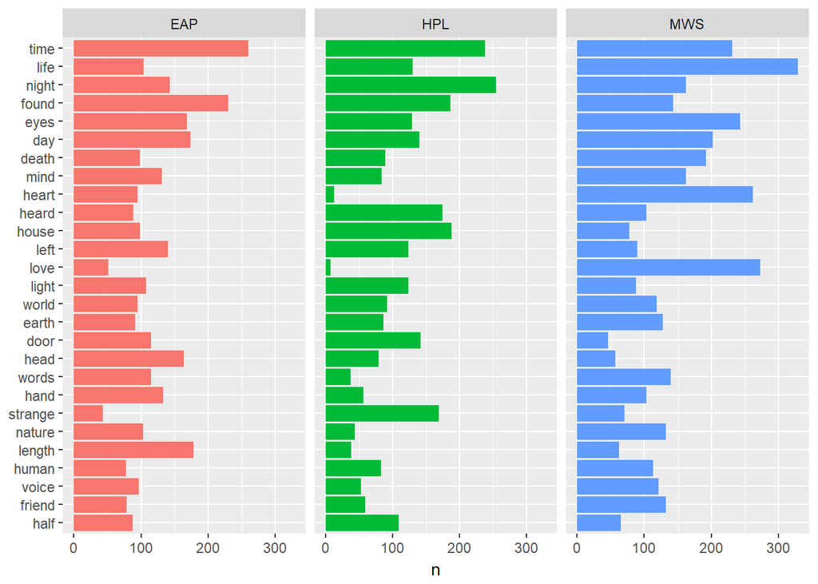

```r
# Counts number of times each author used each unique word
author_words_stop <- count(group_by(spooky_wrd_stop, word, author))

# Counts number of times each unique word was used
all_words_stop    <- rename(count(group_by(spooky_wrd_stop, word)), all = n)

author_words_stop <- left_join(author_words_stop, all_words_stop, by = "word")
author_words_stop <- arrange(author_words_stop, desc(all))
author_words_stop <- ungroup(head(author_words_stop, 81))

ggplot(author_words_stop) +
  geom_col(aes(reorder(word, all, FUN = min), n, fill = author)) +
  xlab(NULL) +
  coord_flip() +
  facet_wrap(~ author) +
  theme(legend.position = "none")
```

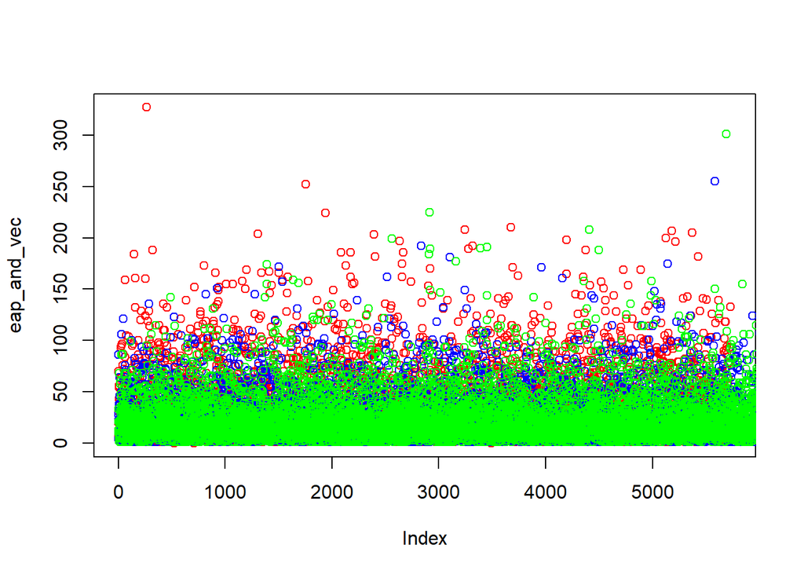

```r
#Load csv files of single words from each individual author
#These files were generated using a SQL Server proc
spooky_eap <- read.csv('../data/spooky_words_eap.csv', as.is = TRUE)
spooky_hpl <- read.csv('../data/spooky_words_hpl.csv', as.is = TRUE)
spooky_mws <- read.csv('../data/spooky_words_mws.csv', as.is = TRUE)

#Create for loop to create a vector with the gaps between each use of a particular word. ie. "and" how many words until the next use of "and" or "life", etc. Intersting words to look at include

#First looking at interesting generic words: and, which, but
#Starting with and for EAP

eap_and_vec <- c()
count_freq <- 0
i <- 1

while (i < length(spooky_eap$X_word_)){
  if(spooky_eap[i,] != "and") {
    count_freq <- count_freq + 1
  }
  else {
    eap_and_vec <- append(eap_and_vec, count_freq)
    count_freq <- 0
  }
  i <- i + 1
}

mean_eap_and <- mean(eap_and_vec)


#Which, EAP

eap_which_vec <- c()
count_freq <- 0
i <- 1

while (i < length(spooky_eap$X_word_)){
  if(spooky_eap[i,] != "which") {
    count_freq <- count_freq + 1
  }
  else {
    eap_which_vec <- append(eap_which_vec, count_freq)
    count_freq <- 0
  }
  i <- i + 1
}

mean_eap_which <- mean(eap_which_vec)

#But, EAP

eap_but_vec <- c()
count_freq <- 0
i <- 1

while (i < length(spooky_eap$X_word_)){
  if(spooky_eap[i,] != "but") {
    count_freq <- count_freq + 1
  }
  else {
    eap_but_vec <- append(eap_but_vec, count_freq)
    count_freq <- 0
  }
  i <- i + 1
}

mean_eap_but <- mean(eap_but_vec)


#And, HPL

hpl_and_vec <- c()
count_freq <- 0
i <- 1

while (i < length(spooky_hpl$ï.._word_)){
  if(spooky_hpl[i,] != "and") {
    count_freq <- count_freq + 1
  }
  else {
    hpl_and_vec <- append(hpl_and_vec, count_freq)
    count_freq <- 0
  }
  i <- i + 1
}

mean_hpl_and <- mean(hpl_and_vec)


#Which, HPL

hpl_which_vec <- c()
count_freq <- 0
i <- 1

while (i < length(spooky_hpl$ï.._word_)){
  if(spooky_hpl[i,] != "which") {
    count_freq <- count_freq + 1
  }
  else {
    hpl_which_vec <- append(hpl_which_vec, count_freq)
    count_freq <- 0
  }
  i <- i + 1
}

mean_hpl_which <- mean(hpl_which_vec)

#But, HPL

hpl_but_vec <- c()
count_freq <- 0
i <- 1

while (i < length(spooky_hpl$ï.._word_)){
  if(spooky_hpl[i,] != "but") {
    count_freq <- count_freq + 1
  }
  else {
    hpl_but_vec <- append(hpl_but_vec, count_freq)
    count_freq <- 0
  }
  i <- i + 1
}

mean_hpl_but <- mean(hpl_but_vec)



#And, MWS

mws_and_vec <- c()
count_freq <- 0
i <- 1

while (i < length(spooky_mws$ï.._word_)){
  if(spooky_mws[i,] != "and") {
    count_freq <- count_freq + 1
  }
  else {
    mws_and_vec <- append(mws_and_vec, count_freq)
    count_freq <- 0
  }
  i <- i + 1
}

mean_mws_and <- mean(mws_and_vec)


#Which, MWS

mws_which_vec <- c()
count_freq <- 0
i <- 1

while (i < length(spooky_mws$ï.._word_)){
  if(spooky_mws[i,] != "which") {
    count_freq <- count_freq + 1
  }
  else {
    mws_which_vec <- append(mws_which_vec, count_freq)
    count_freq <- 0
  }
  i <- i + 1
}

mean_mws_which <- mean(mws_which_vec)

#But, MWS

mws_but_vec <- c()
count_freq <- 0
i <- 1

while (i < length(spooky_mws$ï.._word_)){
  if(spooky_mws[i,] != "but") {
    count_freq <- count_freq + 1
  }
  else {
    mws_but_vec <- append(mws_but_vec, count_freq)
    count_freq <- 0
  }
  i <- i + 1
}

mean_mws_but <- mean(mws_but_vec)


#Now you can compare the plots for each word to see how the frequency between each word changes

#And plot
plot(eap_and_vec, col="red")
points(hpl_and_vec, col="blue")
points(mws_and_vec, col="green")
```

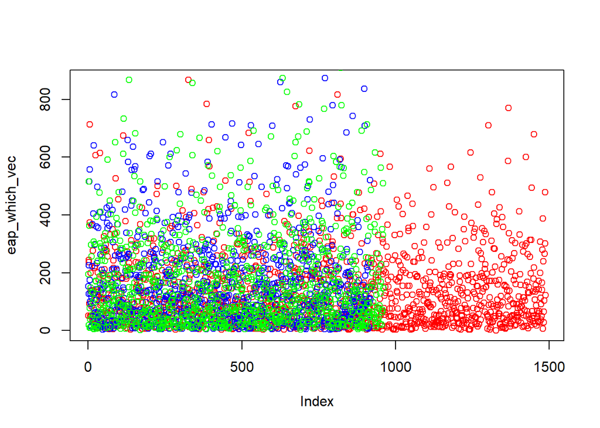

```r
#Which plot
plot(eap_which_vec, col="red")
points(hpl_which_vec, col="blue")
points(mws_which_vec, col="green")
```

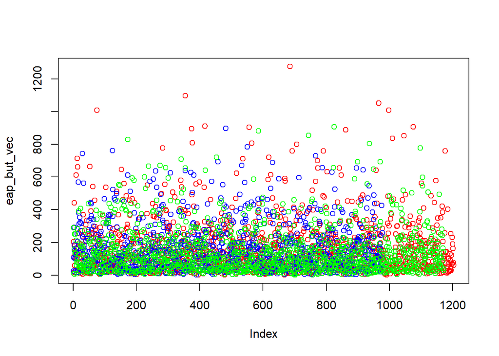

```r
#But plot
plot(eap_but_vec, col="red")
points(hpl_but_vec, col="blue")
points(mws_but_vec, col="green")
```

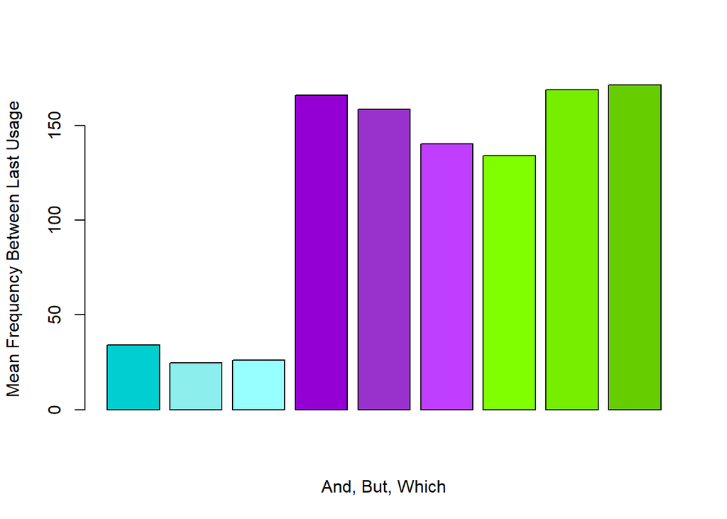

```r
#Next analyze a histogram of the means for each author
author_means <- c(mean_eap_and, mean_hpl_and, mean_mws_and, mean_eap_but, mean_hpl_but, mean_mws_but, mean_eap_which, mean_hpl_which, mean_mws_which)
num_means <- table(author_means)

colors <- c("darkturquoise","darkslategray2", "darkslategray1", "darkviolet", "darkorchid", "darkorchid1", "chartreuse1", "chartreuse2", "chartreuse3")

barplot(author_means, col=colors, ylab = "Mean Frequency Between Last Usage", xlab = "And, But, Which")
```

```r
#EAP unique words: Time

eap_time_vec <- c()
count_freq <- 0
i <- 1

while (i < length(spooky_eap$X_word_)){
  if(spooky_eap[i,] != "time") {
    count_freq <- count_freq + 1
  }
  else {
    eap_time_vec <- append(eap_time_vec, count_freq)
    count_freq <- 0
  }
  i <- i + 1
}

mean_eap_time <- mean(eap_time_vec)
mean_eap_time
```

```
## [1] 769.9038
```

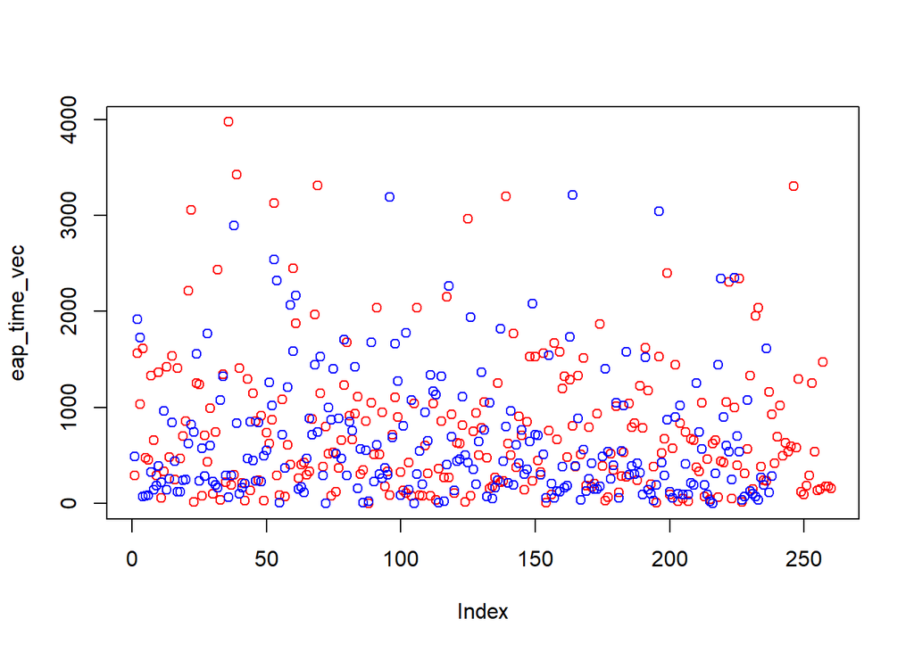

```r
#For comparison, as you can see from what was done with that common words, here is HPL

hpl_time_vec <- c()
count_freq <- 0
i <- 1

while (i < length(spooky_hpl$ï.._word_)){
  if(spooky_hpl[i,] != "time") {
    count_freq <- count_freq + 1
  }
  else {
    hpl_time_vec <- append(hpl_time_vec, count_freq)
    count_freq <- 0
  }
  i <- i + 1
}

plot(eap_time_vec, col="red")
points(hpl_time_vec, col="blue")
```

```r
mean_hpl_time <- mean(hpl_time_vec)
mean_hpl_time
```

```
## [1] 654.0924
```

## Data Visualization

We’ll do some simple numerical summaries of the data to provide some nice visualizations.

```r
p1 <- ggplot(spooky) +
      geom_bar(aes(author, fill = author)) +
      theme(legend.position = "none")


spooky$sen_length <- str_length(spooky$text)
head(spooky$sen_length)
```

```
## [1] 231  71 200 206 174 468
```

```r
p2 <- ggplot(spooky) +
      geom_density_ridges(aes(sen_length, author, fill = author)) +
      scale_x_log10() +
      theme(legend.position = "none") +
      labs(x = "Sentence length [# characters]")


spooky_wrd_stop$word_length <- str_length(spooky_wrd_stop$word)
head(spooky_wrd_stop$word_length)
```

```
## [1]  7  8  5 12 10  7
```

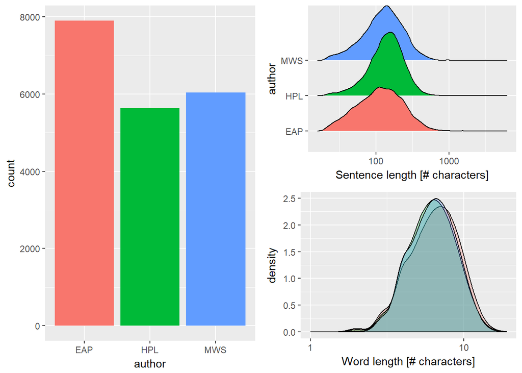

```r
p3 <- ggplot(spooky_wrd_stop) +
      geom_density(aes(word_length, fill = author), bw = 0.05, alpha = 0.3) +
      scale_x_log10() +
      theme(legend.position = "none") +
      labs(x = "Word length [# characters]")

layout <- matrix(c(1, 2, 1, 3), 2, 2, byrow = TRUE)
multiplot(p1, p2, p3, layout = layout)
```

## TF-IDF

TF stands for term frequency or how often a word appears in a text and it is what is studied above in the word cloud. IDF stands for inverse document frequency, and it is a way to pay more attention to words that are rare within the entire set of text data that is more sophisticated than simply removing stop words. Multiplying these two values together calculates a term’s tf-idf, which is the frequency of a term adjusted for how rarely it is used. We’ll use tf-idf as a heuristic index to indicate how frequently a certain author uses a word relative to the frequency that ll the authors use the word. Therefore we will find words that are characteristic for a specific author, a good thing to have if we are interested in solving the author identification problem.

```r
frequency <- count(spooky_wrd, author, word)
tf_idf    <- bind_tf_idf(frequency, word, author, n)
head(tf_idf)
```

```
## # A tibble: 6 x 6
##   author word      n         tf   idf     tf_idf
##   <fct>  <chr> <int>      <dbl> <dbl>      <dbl>
## 1 EAP    a      4728 0.0235     0     0
## 2 EAP    ã        19 0.0000945  0.405 0.0000383
## 3 EAP    a.m       3 0.0000149  0.405 0.00000605
## 4 EAP    aaem      1 0.00000498 1.10  0.00000547
## 5 EAP    ab        1 0.00000498 1.10  0.00000547
## 6 EAP    aback     2 0.00000995 1.10  0.0000109
```

```r
tail(tf_idf)
```

```
## # A tibble: 6 x 6
##   author word         n         tf   idf     tf_idf
##   <fct>  <chr>    <int>      <dbl> <dbl>      <dbl>
## 1 MWS    youth's      1 0.00000604 0.405 0.00000245
## 2 MWS    youthful    10 0.0000604  0     0
## 3 MWS    youths       2 0.0000121  0.405 0.00000489
## 4 MWS    zaimi        2 0.0000121  1.10  0.0000133
## 5 MWS    zeal         7 0.0000422  0     0
## 6 MWS    zest         3 0.0000181  0     0
```

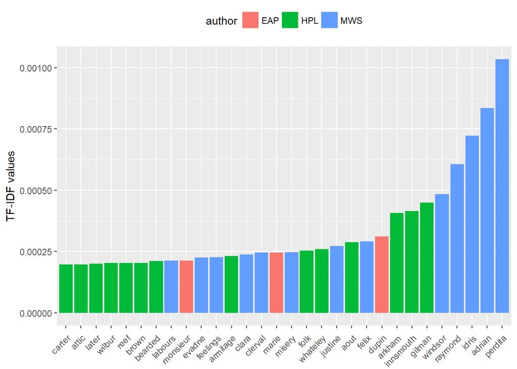

```r
tf_idf    <- arrange(tf_idf, desc(tf_idf))
tf_idf    <- mutate(tf_idf, word = factor(word, levels = rev(unique(word))))

# Grab the top thirty tf_idf scores in all the words
tf_idf_30 <- top_n(tf_idf, 30, tf_idf)

ggplot(tf_idf_30) +
  geom_col(aes(word, tf_idf, fill = author)) +
  labs(x = NULL, y = "TF-IDF values") +
  theme(legend.position = "top", axis.text.x  = element_text(angle=45, hjust=1, vjust=0.9))
```

Note that in the above, many of the words recognized by their tf-idf scores are names. This makes sense – if we see text referencing Raymond, Idris, or Perdita, we know almost for sure that MWS is the author. But some non-names stand out. EAP often uses “monsieur” and “jupiter” while HPL uses the words “bearded” and “attic” more frequently than the others. We can also look at the most characteristic terms per author.

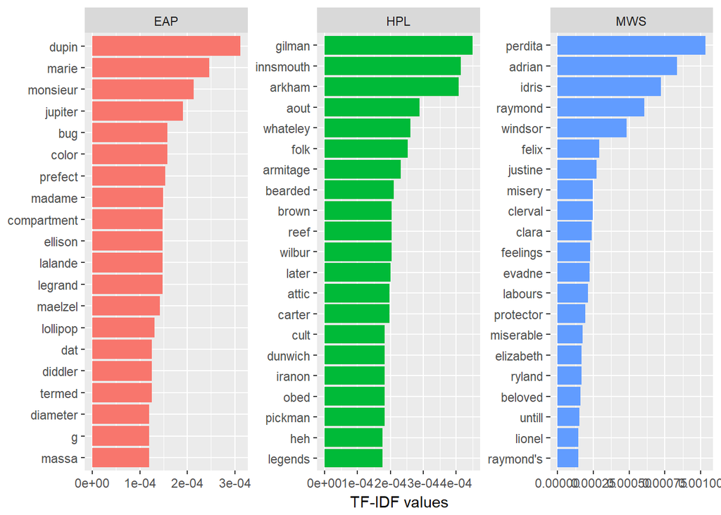

```r
# Grab the top twenty tf_idf scores in all the words for each author
tf_idf <- ungroup(top_n(group_by(tf_idf, author), 20, tf_idf))

ggplot(tf_idf) +
  geom_col(aes(word, tf_idf, fill = author)) +
  labs(x = NULL, y = "tf-idf") +
  theme(legend.position = "none") +
  facet_wrap(~ author, ncol = 3, scales = "free") +
  coord_flip() +
  labs(y = "TF-IDF values")
```

# Sentiment Analysis

We will use sentences as units of analysis for this part of the tutorial, as sentences are natural languge units for organizing thoughts and ideas. For each sentence, we apply sentiment analysis using [NRC sentiment lexion](http://saifmohammad.com/WebPages/NRC-Emotion-Lexicon.htm). “The NRC Emotion Lexicon is a list of English words and their associations with eight basic emotions (anger, fear, anticipation, trust, surprise, sadness, joy, and disgust) and two sentiments (negative and positive). The annotations were manually done by crowdsourcing.”

From *[Text Mining with R; A Tidy Approach](https://www.tidytextmining.com)*, “When human readers approach text, we use our understanding of the emotional intent of words to infer whether a section of text is positive or negative, or perhaps characterized by some other more nuanced emotion like surprise or disgust. We can also use the tools of text mining to approach the emotional content of text programmatically.” This is the goal of sentiment analysis.

```r
# Keep words that have been classified within the NRC lexicon.
get_sentiments('nrc')
```

```
## # A tibble: 13,901 x 2
##    word        sentiment
##    <chr>       <chr>
##  1 abacus      trust
##  2 abandon     fear
##  3 abandon     negative
##  4 abandon     sadness
##  5 abandoned   anger
##  6 abandoned   fear
##  7 abandoned   negative
##  8 abandoned   sadness
##  9 abandonment anger
## 10 abandonment fear
## # ... with 13,891 more rows
```

```r
sentiments <- inner_join(spooky_wrd, get_sentiments('nrc'), by = "word")

count(sentiments, sentiment)
```

```
## # A tibble: 10 x 2
##    sentiment        n
##    <chr>        <int>
##  1 anger         9869
##  2 anticipation 12912
##  3 disgust       7731
##  4 fear         14096
##  5 joy          11077
##  6 negative     24084
##  7 positive     26934
##  8 sadness      12896
##  9 surprise      6904
## 10 trust        14777
```

```r
count(sentiments, author, sentiment)
```

```
## # A tibble: 30 x 3
##    author sentiment        n
##    <fct>  <chr>        <int>
##  1 EAP    anger         2962
##  2 EAP    anticipation  4656
##  3 EAP    disgust       2273
##  4 EAP    fear          4287
##  5 EAP    joy           3652
##  6 EAP    negative      7833
##  7 EAP    positive     10083
##  8 EAP    sadness       4045
##  9 EAP    surprise      2539
## 10 EAP    trust         5739
## # ... with 20 more rows
```

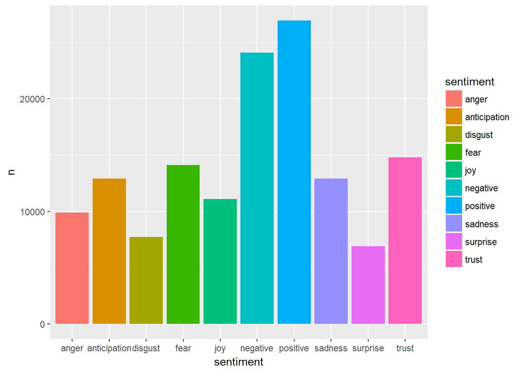

```r
ggplot(count(sentiments, sentiment)) +
  geom_col(aes(sentiment, n, fill = sentiment))
```

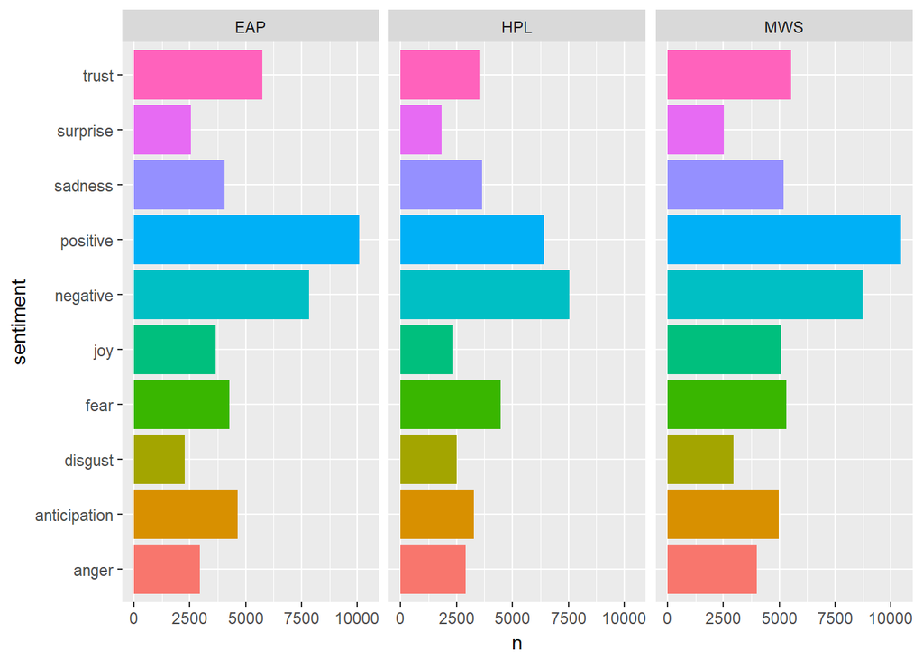

```r
ggplot(count(sentiments, author, sentiment)) +
  geom_col(aes(sentiment, n, fill = sentiment)) +
  facet_wrap(~ author) +
  coord_flip() +
  theme(legend.position = "none")
```

## Comparing Positivity

Let’s only study the “positive” words. Note that the amount of “postive” words attributed to each author varies greatly, and the relative frequency of “positive” words to the other sentiments also varies between authors.

```r
nrc_pos <- filter(get_sentiments('nrc'), sentiment == "positive")
nrc_pos
```

```
## # A tibble: 2,312 x 2
##    word           sentiment
##    <chr>          <chr>
##  1 abba           positive
##  2 ability        positive
##  3 abovementioned positive
##  4 absolute       positive
##  5 absolution     positive
##  6 absorbed       positive
##  7 abundance      positive
##  8 abundant       positive
##  9 academic       positive
## 10 academy        positive
## # ... with 2,302 more rows
```

```r
positive <- inner_join(spooky_wrd, nrc_pos, by = "word")
head(positive)
```

```
##        id author     word sentiment
## 1 id11008    EAP     gold  positive
## 2 id27763    MWS   lovely  positive
## 3 id27763    MWS  fertile  positive
## 4 id27763    MWS    happy  positive
## 5 id27763    MWS cheering  positive
## 6 id27763    MWS     fair  positive
```

```r
count(positive, word, sort = TRUE)
```

```
## # A tibble: 1,708 x 2
##    word       n
##    <chr>  <int>
##  1 found    559
##  2 love     331
##  3 good     277
##  4 friend   270
##  5 sea      243
##  6 young    228
##  7 full     226
##  8 spirit   202
##  9 hope     195
## 10 kind     185
## # ... with 1,698 more rows
```

Now we plot a frequency comparison of these “positive” words. Namely, we show the frequencies of the overall most frequently-used positive words split between the three authors.

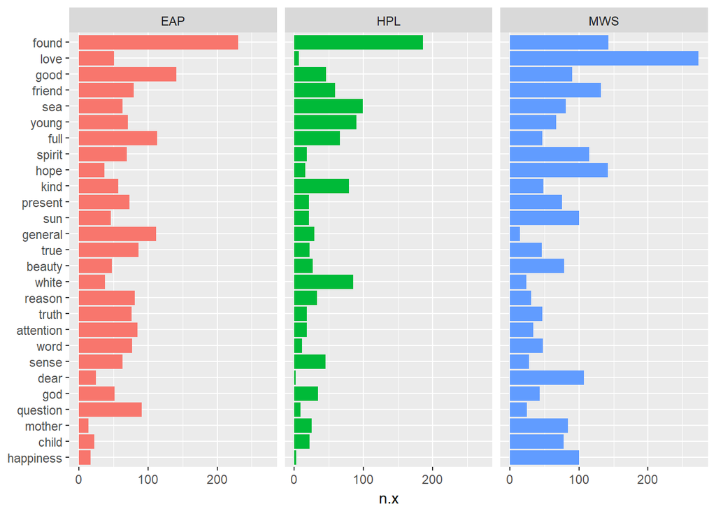

```r
pos_words     <- count(group_by(positive, word, author))
pos_words_all <- count(group_by(positive, word))

pos_words <- left_join(pos_words, pos_words_all, by = "word")
pos_words <- arrange(pos_words, desc(n.y))
pos_words <- ungroup(head(pos_words, 81))

# Note the above is the same as
# pos_words <- pos_words  %>%
#                left_join(pos_words_all, by = "word") %>%
#                arrange(desc(n.y)) %>%
#                head(81) %>%
#                ungroup()

ggplot(pos_words) +
  geom_col(aes(reorder(word, n.y, FUN = min), n.x, fill = author)) +
  xlab(NULL) +
  coord_flip() +
  facet_wrap(~ author) +
  theme(legend.position = "none")
```